# PalmerPenguins

2022-06-04

This is an R Markdown document; see here for details http://rmarkdown.rstudio.com.

# COURSERA GOOGLE LEARNING WITH PALMER PENGUINS

This exercise asks a basic question: Is there a causal relationship between body size and flipper length?

### More specifically, our question is: how well does body size predict flipper length?

**Independent Variable: Body Size

Dependent Variable: Flipper Length**

## Step 1 is installing all relevant packages and libraries.

These are broken out in many individual library commands instead of comma-delimited lists just for readability. I use base R, plus the tidyverse, plus lessR.

```r
install.packages("tidyverse")
install.packages("lessR")
library(tidyverse)
```

```r
library(ggplot2)
library(dplyr)
library(tidyr)
library(purrr)
library(stringr)
library(forcats)
library(readr)
library(lubridate)
library(hms)
library(lessR)
```

## Step 2 is loading data as a Tibble and doing Exploratory Data Analysis (EDA).

First, we load/import the dataset(s) and convert to a Tibble using “as_tibble()”.

Second, we look at its overall structure and properties.

We use “dim” to see how many rows and columns we have, followed by “str” to provide a high level explanation of each column’s data type. Then we use “glimpse” to preview the actual values in each row. Then we use “summary” to get basic descriptive statistics and “view” to open a new tab to look at the Tibble column by column.

```r
library(palmerpenguins)
importTIB <- as_tibble(penguins)
dim(importTIB)
```

```
## [1] 344   8
```

```r
str(importTIB)
```

```
## tibble [344 × 8] (S3: tbl_df/tbl/data.frame)
##  $ species          : Factor w/ 3 levels "Adelie","Chinstrap",..: 1 1 1 1 1 1 1 1 1 1 ...
##  $ island           : Factor w/ 3 levels "Biscoe","Dream",..: 3 3 3 3 3 3 3 3 3 3 ...
##  $ bill_length_mm   : num [1:344] 39.1 39.5 40.3 NA 36.7 39.3 38.9 39.2 34.1 42 ...
##  $ bill_depth_mm    : num [1:344] 18.7 17.4 18 NA 19.3 20.6 17.8 19.6 18.1 20.2 ...
##  $ flipper_length_mm: int [1:344] 181 186 195 NA 193 190 181 195 193 190 ...
##  $ body_mass_g      : int [1:344] 3750 3800 3250 NA 3450 3650 3625 4675 3475 4250 ...
##  $ sex              : Factor w/ 2 levels "female","male": 2 1 1 NA 1 2 1 2 NA NA ...
##  $ year             : int [1:344] 2007 2007 2007 2007 2007 2007 2007 2007 2007 2007 ...
```

```r
glimpse(importTIB)
```

```
## Rows: 344
## Columns: 8
## $ species           <fct> Adelie, Adelie, Adelie, Adelie, Adelie, Adelie, Adel…
## $ island            <fct> Torgersen, Torgersen, Torgersen, Torgersen, Torgerse…
## $ bill_length_mm    <dbl> 39.1, 39.5, 40.3, NA, 36.7, 39.3, 38.9, 39.2, 34.1, …
## $ bill_depth_mm     <dbl> 18.7, 17.4, 18.0, NA, 19.3, 20.6, 17.8, 19.6, 18.1, …
## $ flipper_length_mm <int> 181, 186, 195, NA, 193, 190, 181, 195, 193, 190, 186…
## $ body_mass_g       <int> 3750, 3800, 3250, NA, 3450, 3650, 3625, 4675, 3475, …
## $ sex               <fct> male, female, female, NA, female, male, female, male…
## $ year              <int> 2007, 2007, 2007, 2007, 2007, 2007, 2007, 2007, 2007…
```

```r
summary(importTIB)
```

```
##       species          island    bill_length_mm  bill_depth_mm
##  Adelie   :152   Biscoe   :168   Min.   :32.10   Min.   :13.10
##  Chinstrap: 68   Dream    :124   1st Qu.:39.23   1st Qu.:15.60
##  Gentoo   :124   Torgersen: 52   Median :44.45   Median :17.30
##                                  Mean   :43.92   Mean   :17.15
##                                  3rd Qu.:48.50   3rd Qu.:18.70
##                                  Max.   :59.60   Max.   :21.50
##                                  NA's   :2       NA's   :2
##  flipper_length_mm  body_mass_g       sex           year
##  Min.   :172.0     Min.   :2700   female:165   Min.   :2007
##  1st Qu.:190.0     1st Qu.:3550   male  :168   1st Qu.:2007
##  Median :197.0     Median :4050   NA's  : 11   Median :2008
##  Mean   :200.9     Mean   :4202                Mean   :2008
##  3rd Qu.:213.0     3rd Qu.:4750                3rd Qu.:2009
##  Max.   :231.0     Max.   :6300                Max.   :2009
##  NA's   :2         NA's   :2
```

```r
view(importTIB)
```

## EDA: First, let’s drop the few NA values we have, and then check distribution and central tendency.

```r
dataTIB <- na.omit(importTIB)
```

We also see that penguin bill length has an almost bi-modal distribution. Despite this, both have a mean and a median that are close together.

```r
summary(dataTIB$bill_length_mm)
```

```
##    Min. 1st Qu.  Median    Mean 3rd Qu.    Max.
##   32.10   39.50   44.50   43.99   48.60   59.60
```

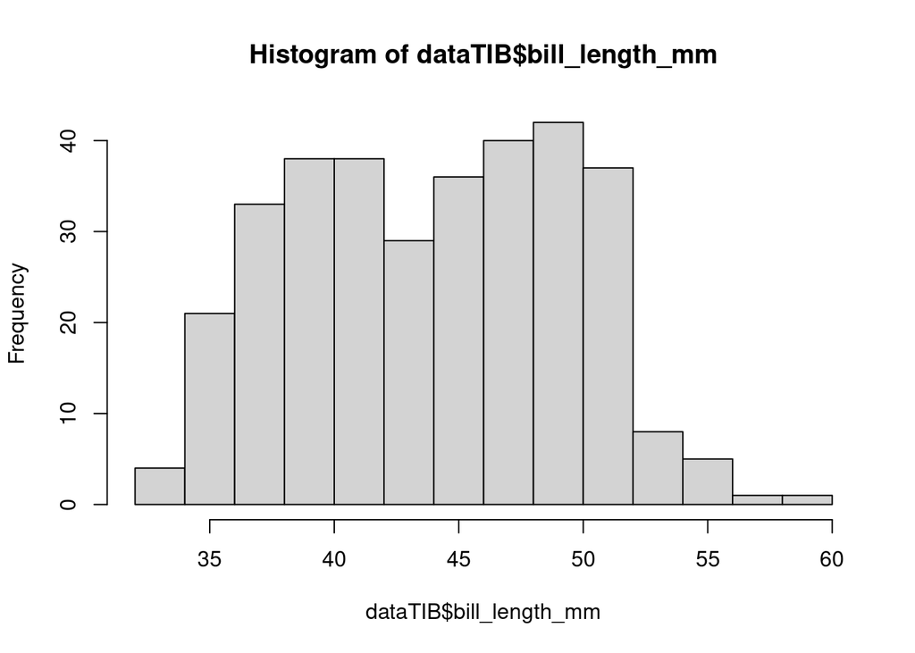

```r
hist(dataTIB$bill_length_mm)
```

```r
summary(dataTIB$body_mass_g)
```

```
##    Min. 1st Qu.  Median    Mean 3rd Qu.    Max.
##    2700    3550    4050    4207    4775    6300
```

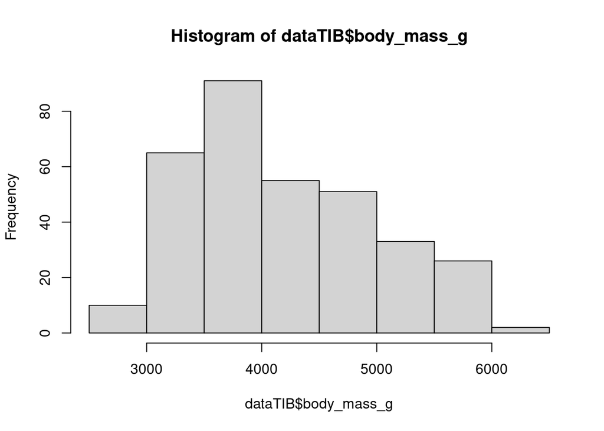

```r
hist(dataTIB$body_mass_g)
```

## More EDA: checking the dispersion of two related variables

We also want to look at the data’s dispersion, looking at “min” and “max” values, plus the “range” and “IQR” for Inter-Quartile Range (IQR), plus the tried and true standard measure of dispersion, the Standard Deviation or “SD”. We also use the “Plot” function which will visualize the central tendency and dispersion in a violin plot that visualizes the interquartile range. This will let us get an understanding of the data that goes deeper than just the basic histogram or box-and-whisker plot.

```r
min(dataTIB$bill_length_mm, na.rm=TRUE)
```

```
## [1] 32.1
```

```r
max(dataTIB$bill_length_mm, na.rm=TRUE)
```

```
## [1] 59.6
```

```r
range(dataTIB$bill_length_mm, na.rm=TRUE)
```

```
## [1] 32.1 59.6
```

```r
IQR(dataTIB$bill_length_mm, na.rm=TRUE)
```

```
## [1] 9.1
```

```r
sd(dataTIB$bill_length_mm, na.rm=TRUE)
```

```
## [1] 5.468668
```

The violin plot visualizes how, for bill length, data is actually quite dispersed, with many points laying outside of the middle 50% of the IQR.

```
## [Violin/Box/Scatterplot graphics from Deepayan Sarkar's lattice package]
## >>> Suggestions
## Plot(bill_length_mm, out_cut=2, fences=TRUE, vbs_mean=TRUE)  # Label two outliers ...
## Plot(bill_length_mm, box_adj=TRUE)  # Adjust boxplot whiskers for asymmetry
```

```
## The default of 'doScale' is FALSE now for stability;
##   set options(mc_doScale_quiet=TRUE) to suppress this (once per session) message
```

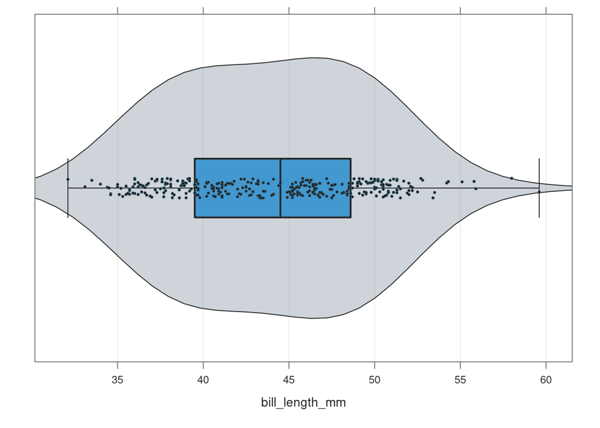

```
## --- bill_length_mm ---
## Present: 333
## Missing: 0
## Total  : 333
##
## Mean         : 43.99
## Stnd Dev     : 5.47
## IQR          : 9.10
## Skew         : -0.13   [medcouple, -1 to 1]
##
## Minimum      : 32.10
## Lower Whisker: 32.10
## 1st Quartile : 39.50
## Median       : 44.50
## 3rd Quartile : 48.60
## Upper Whisker: 59.60
## Maximum      : 59.60
##
## No (Box plot) outliers
##
##                Max Dupli-
## Level           cations   Values
## ------------------------------
## bill_length_mm      7     41.1
##
## Parameter values (can be manually set)
## -------------------------------------------------------
## size: 0.32      size of plotted points
## out_size: 0.71  size of plotted outlier points
## jitter_y: 1.72 random vertical movement of points
## jitter_x: 0.21  random horizontal movement of points
## bw: 3.00       set bandwidth higher for smoother edges
```

```r
Plot(bill_length_mm, data=dataTIB)
```

```r
min(dataTIB$body_mass_g, na.rm=TRUE)
```

```
## [1] 2700
```

```r
max(dataTIB$body_mass_g, na.rm=TRUE)
```

```
## [1] 6300
```

```r
range(dataTIB$body_mass_g, na.rm=TRUE)
```

```
## [1] 2700 6300
```

```r
IQR(dataTIB$body_mass_g, na.rm=TRUE)
```

```
## [1] 1225
```

```r
sd(dataTIB$body_mass_g, na.rm=TRUE)
```

```
## [1] 805.2158
```

The violin plot visualizes how, for body mass, data is slightly less dispersed, but with a larger probability of values on the lower end, and some higher end values skewing it right.

```
## [Violin/Box/Scatterplot graphics from Deepayan Sarkar's lattice package]
## >>> Suggestions
## Plot(body_mass_g, out_cut=2, fences=TRUE, vbs_mean=TRUE)  # Label two outliers ...
## Plot(body_mass_g, box_adj=TRUE)  # Adjust boxplot whiskers for asymmetry
```

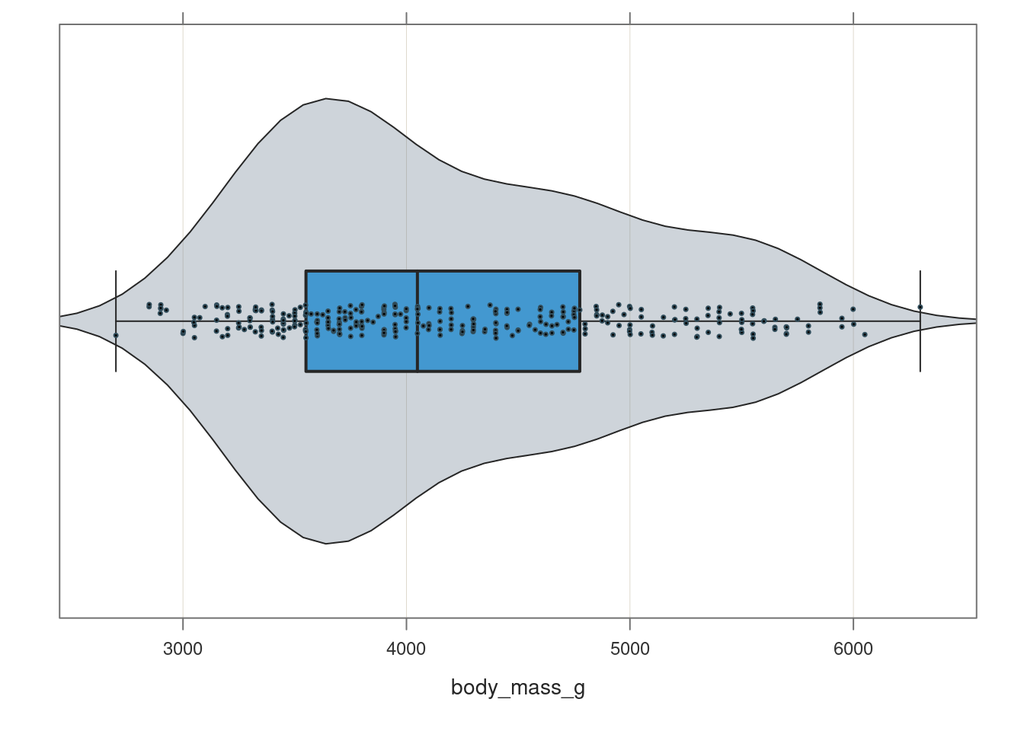

```
## --- body_mass_g ---
## Present: 333
## Missing: 0
## Total  : 333
##
## Mean         : 4207.06
## Stnd Dev     : 805.22
## IQR          : 1225.00
## Skew         : 0.24   [medcouple, -1 to 1]
##
## Minimum      : 2700.00
## Lower Whisker: 2700.00
## 1st Quartile : 3550.00
## Median       : 4050.00
## 3rd Quartile : 4775.00
## Upper Whisker: 6300.00
## Maximum      : 6300.00
##
## No (Box plot) outliers
##
##             Max Dupli-
## Level        cations   Values
## ------------------------------
## body_mass_g     12     3800
##
## Parameter values (can be manually set)
## -------------------------------------------------------
## size: 0.32      size of plotted points
## out_size: 0.71  size of plotted outlier points
## jitter_y: 1.72 random vertical movement of points
## jitter_x: 0.33  random horizontal movement of points
## bw: 226.81       set bandwidth higher for smoother edges
```

```r
Plot(body_mass_g, data=dataTIB)
```

## Step 3: Hypothesizing a model

So we can see that our two variables are not very normally distributed, nor do they have low dispersion - not a great sign for using a standard linear model regression. But, since this is just to learn, let’s see if we can find a line of best fit with these two. Again, our question is: how well does body size predict flipper length?

**Independent Variable: Body Size

Dependent Variable: Flipper Length**

So now let’s plot these two variables and see what sort of relationship they might have.

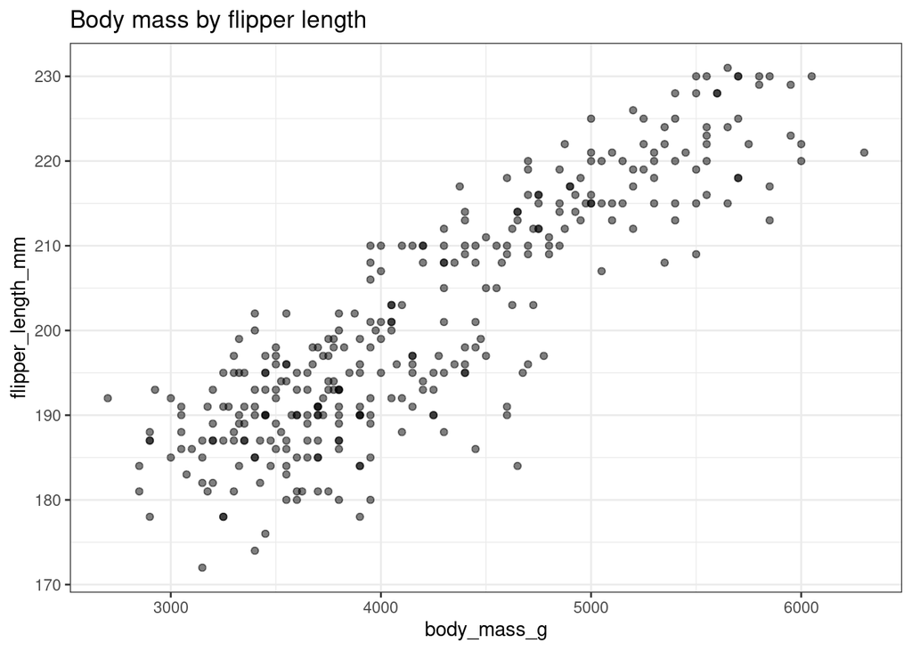

```r
ggplot(dataTIB, aes(body_mass_g, flipper_length_mm)) +
  geom_point(alpha = 0.5) +
  labs(title = "Body mass by flipper length") +
  theme_bw()
```

## Hypothesizing a model: an apparent linear relationship

We can now plot a line of best fit using “geom_smooth(method = lm)”. As it shows, there is a fairly direct relationship between the penguins’ body mass and flipper length, overall, without considering the impact of some of the other possible causal variables.

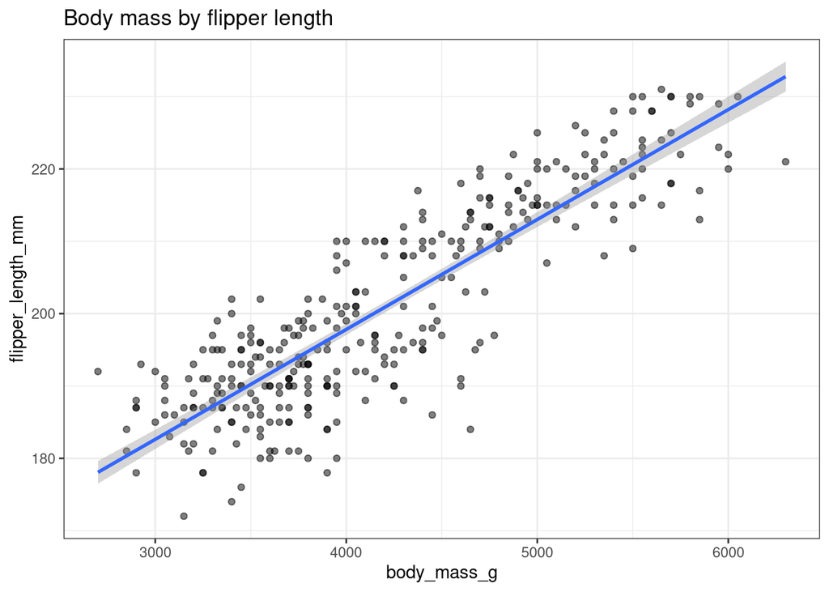

```r
ggplot(dataTIB, aes(body_mass_g, flipper_length_mm)) +
    geom_point(alpha = 0.5) +
    geom_smooth(method = lm, na.rm = TRUE) +
    labs(title = "Body mass by flipper length") +
    theme_bw()
```

We know that there are three other variables in this dataset that might cause, or at least impact, flipper length. * Biological Sex * Penguin Species * Island Location

Adding the “facet_wrap()” argument within the “ggplot” function, we can do a side-by-side of our mass-length proposed model to see if any of these other variables seriously disrupt that model. As the below indicate, the mass-length relationship remains quite clear even when looking at it based on these other three variables.

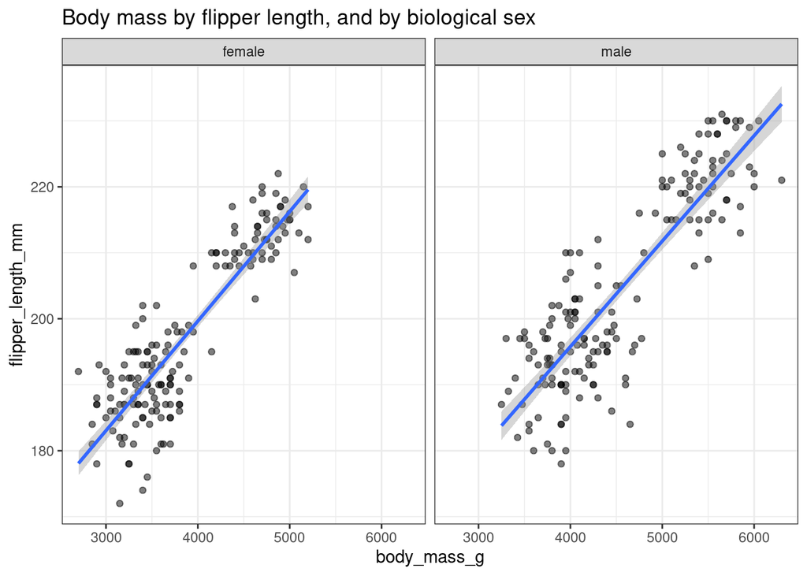

```r
ggplot(dataTIB, aes(body_mass_g, flipper_length_mm)) +
  geom_point(alpha = 0.5) +
  labs(title = "Body mass by flipper length, and by biological sex") +
  theme_bw() +
  geom_smooth(method = lm, na.rm = TRUE)+
  facet_wrap(~sex)
```

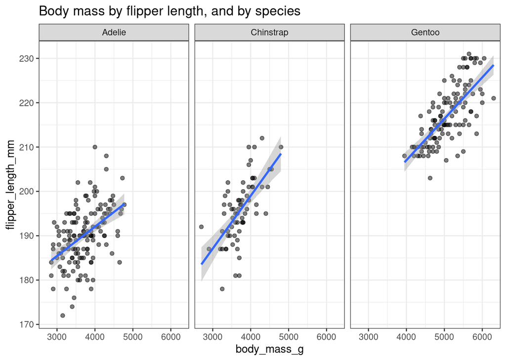

```r
ggplot(dataTIB, aes(body_mass_g, flipper_length_mm)) +
  geom_point(alpha = 0.5) +
  labs(title = "Body mass by flipper length, and by species") +
  theme_bw() +
  geom_smooth(method = lm, na.rm = TRUE)+
  facet_wrap(~species)
```

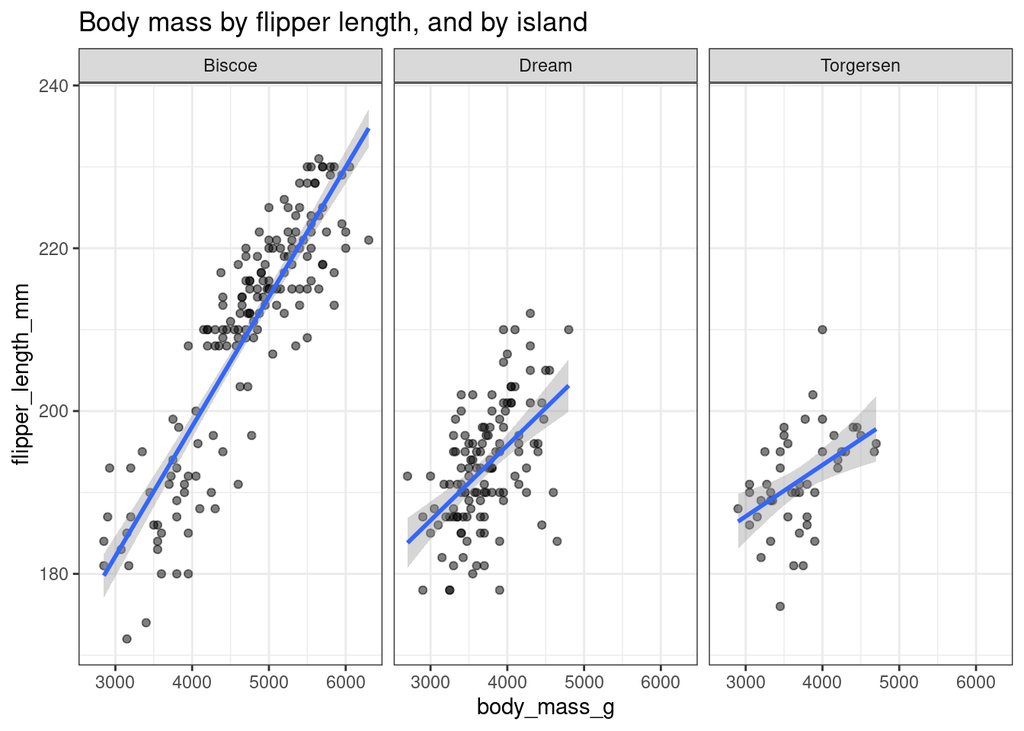

```r
ggplot(dataTIB, aes(body_mass_g, flipper_length_mm)) +
  geom_point(alpha = 0.5) +
  labs(title = "Body mass by flipper length, and by island") +
  theme_bw() +
  geom_smooth(method = lm, na.rm = TRUE)+
  facet_wrap(~island)
```

## Step 4: Running regressions (simple linear bivariate)

Visuals with a line of best fit give an intuitive, overall explanation of the positive, probably causal relationship between the causal/independent variable and the dependent variable. We should also run a regression and look at its output to confirm the magnitude of the relationship. We want to see an R-squared (“R^2”) values close to 1, and a P-value close to 0. This is just going more mathematically in-depth to the linear model (“lm”) we inserted into the visuals above.

```r
bivariate.regression <- lm(flipper_length_mm ~ body_mass_g, data = dataTIB)
summary(bivariate.regression)
```

```
##
## Call:
## lm(formula = flipper_length_mm ~ body_mass_g, data = dataTIB)
##
## Residuals:
##     Min      1Q  Median      3Q     Max
## -23.698  -4.983   1.056   5.101  13.933
##
## Coefficients:
##                Estimate  Std. Error t value            Pr(>|t|)
## (Intercept) 137.0396209   1.9987694   68.56 <0.0000000000000002 ***
## body_mass_g   0.0151953   0.0004667   32.56 <0.0000000000000002 ***
## ---
## Signif. codes:  0 '***' 0.001 '**' 0.01 '*' 0.05 '.' 0.1 ' ' 1
##
## Residual standard error: 6.847 on 331 degrees of freedom
## Multiple R-squared:  0.7621, Adjusted R-squared:  0.7614
## F-statistic:  1060 on 1 and 331 DF,  p-value: < 0.00000000000000022
```

We can see that R^2 is about 0.76, which is not as close to 1 as we’d like, but is still a fairly strong linear relationship.

## Running regressions (multi-variate, controlling for other variables)

Finally, let’s see if our probably causal variable is still reliable at predicting the dependent variable when we factor in other possibly causal / confounding variables.

```r
multivariate.regression <- lm(flipper_length_mm ~ body_mass_g + sex + island + species, data = dataTIB)
summary(multivariate.regression)
```

```
##
## Call:
## lm(formula = flipper_length_mm ~ body_mass_g + sex + island +
##     species, data = dataTIB)
##
## Residuals:
##      Min       1Q   Median       3Q      Max
## -14.4515  -3.1756  -0.0639   3.1517  15.2879
##
## Coefficients:
##                    Estimate Std. Error t value             Pr(>|t|)
## (Intercept)      163.308460   3.236687  50.455 < 0.0000000000000002 ***
## body_mass_g        0.006534   0.000925   7.064     0.00000000000986 ***
## sexmale            2.498202   0.848734   2.943              0.00348 **
## islandDream        1.163307   1.074299   1.083              0.27967
## islandTorgersen    2.770541   1.114126   2.487              0.01339 *
## speciesChinstrap   5.711688   0.963798   5.926     0.00000000788397 ***
## speciesGentoo     19.373659   1.579314  12.267 < 0.0000000000000002 ***
## ---
## Signif. codes:  0 '***' 0.001 '**' 0.01 '*' 0.05 '.' 0.1 ' ' 1
##
## Residual standard error: 5.311 on 326 degrees of freedom
## Multiple R-squared:  0.859,  Adjusted R-squared:  0.8564
## F-statistic:   331 on 6 and 326 DF,  p-value: < 0.00000000000000022
```

Good news!

# CONCLUSIONS AND NEXT STEPS

## BODY MASS IS A GOOD PREDICTOR OF FLIPPER LENGTH

This data shows that overall, even when controlling for other possibly causal variables, body mass is a reliable predictor of flipper length.

There are a few other questions to think about that might be good next steps.

- 1. Is the inverse true: is there a causal relationship between flipper length and body mass?
- 2. What about sex or bill depth: do either of those cause larger body mass, or larger flipper length?
- 3. Which of these causal relationships is the strongest and most reliable predictor?